# First SDMS Assignment

## Deadine: 13/04/2023

### What are these assignments?

Assignments are some exercise to do in python in a due date. They:

- are compulsory
- give from 0 to 2 **bonus points** to the exam depending on how much well they are done, so you can still take 30 cum laude even if you take 0 to all the assignments .
- at first they will be evaluated based on: correctness, speed of code execution, clarity, original ideas. The evaluation methods are in descending order.
- Because it is the first time I make assigments, I decided to make an additional rule to help you. Let $$X_{1},...X_{n}$$ the votes of the $n$ students, the vote that will be registered will be $$Y_{i}=X_{i}+[2-\max_{i}X_{i}]$$.
- Send your assignment to my email: guglielmo.padula@studenti.units.it before the 00:00 AM of the day after the deadiline.

### What if I don't do one of them?

In case you don't manage to do all the assignments there will be a general course assigment will be published a week or two before the first exam date. There will be an exercise for each "partial" assigment (you will be required to do only the exercises corresponding to the assigments that you did not do). The additional rule for the marks may or may not hold (it will depend on the statistical sample).

### Exercise 0 (Optional)

Prove that $$P(Y_{i}\ge X_{i})=1 \quad \forall i=1...n$$

### Exercise 1: Monte Carlo Integration

As I already said in the first lab, let $X$ a random variable and $G$ a function such that $Var(G(X))\le +\infty$ then if $x_{1},....,x_{n}$ are a sample from $X$ then $\lim \limits_{n\rightarrow +\infty} \frac{1}{n}\sum\limits_{i=1}^{n} G(x_{i})=E[G(X)]$

All the 2D triangles with a vertex in the origin can be described by a quadruple $P=(A,B,C,D)\in \mathbb{R}^{4}$ where $(A,B)$ and $(C,D)$ are the coordinates in the $XY$ plane of the other two vertices.

It can be proven that with this parametrization the area of a triangle is $$Area(P)=\frac{1}{2}|A*D-B*C|=\frac{1}{2}|(A,B)\times (C,D)|$$ where $\times$ is the cross-product.

Assume that $$A\sim Beta(1,1)$$ $$B\sim Beta(1,1)$$ $$C\sim Beta(1,1)$$ $$D\sim Beta(1,1)$$ and that $A,B,C,D$ are completely independent (so you can simply sample each other independently).

Exercise:

- 1. estimate $Area(P)$ using Monte Carlo Integration. You can sample from a beta distribution using scipy.stats.beta
- 2. (optional, you can also do this and not do 1.) the monte carlo estimation of $Area(P)$ can be calculated in only line of code (imports excluded) using numpy vectorization, try to do it.
- 3. (optional, do only if you did both points 1. and 2.) compare the time of execution of your implementations using the function time from the python module time. Do the comparison with $n=50$, $n=500$, $n=5000$, $n=50000$.
- 4. (optional) prove that $Var(Area(P))< +\infty$

### Exercise 2:

Let's take the Cow-Vegetation model with $r=1,k=10,\beta=1,V_{0}=1$, i.e $\dot{X}=X\left(1-\frac{X}{100}\right)-H\left(\frac{X^{2}}{X^{2}+1}\right)$ where $H$ is the number of cows. For the values of $H=1,2,3$ do the simulation with using a sequence of starting points from $0$ to $10$ (use at least $100$ intermediate points) until $t=10$ and try to understand how many equibrium points there are for each value of $H$, if they are stable or unstable and try to estimate their numerical value by looking at the graph (a nonprecise estimate is ok). Feel free to recycle my class for basic Continous Dinamical 1d systems.

### Exercise 3:

Study the following dynamical system: $y_{n+1}=0.5\left(y_n^2-3 y_{n}+6\right)$ for starting points $y_{0}$ which range from $1$ to $3$ (use at least $100$ intermediate points) until $t=10$ and try to understand how many equibrium points there are, if they are stable or unstable and try to estimate their numerical value by looking at the graph (a nonprecise estimate is ok). Feel free to recycle my class for basic Discrete Dinamical 1d systems.

# Solutions

## Exercise 1

#### 1.

Supposing that $Var(Area(P))< +\infty$, we can sample A, B, C and D from a $Beta(1,1)$, and estimate the area as the average of its value computed on the sampled verteces. The larger the sample the closer the estimated value to the true one.

```python
# importing and setting sample size and vertex distribution

from scipy.stats import beta
import numpy as np

sample_size = 10000
vertex_dist = beta
```

```python
# sampling verteces

A = np.empty(sample_size)
B = np.empty(sample_size)
C = np.empty(sample_size)
D = np.empty(sample_size)

A = vertex_dist.rvs(1, 1, size=sample_size)
B = vertex_dist.rvs(1, 1, size=sample_size)
C = vertex_dist.rvs(1, 1, size=sample_size)
D = vertex_dist.rvs(1, 1, size=sample_size)
```

```python
# estimating Area using sampled verteces

Area = np.empty(sample_size)
Area = 0.5 * np.fabs(A*D - B*C)
Area_estimated = np.sum(Area) / sample_size
```

```python
print(Area_estimated)
```

```
0.11961554222736799
```

#### 2.

```python
# using numpy vectorization to compute the estimation in just one line

Area_estimated_one_line = 0.5 * np.sum(np.fabs(beta.rvs(1, 1, size=1000)*beta.rvs(1, 1, size=1000)
                                               - beta.rvs(1, 1, size=1000)*beta.rvs(1, 1, size=1000)
                                               )) / 1000
```

```python
print(Area_estimated_one_line)
```

```
0.12059151672635289
```

#### 3.

```python
# importing time function and pandas to display results

from time import time
import pandas as pd
```

```python
# measuring extended version time

test_1 = []

for samp_size in (50, 500, 5000, 50000):

    start = time()

    vertex_dist = beta

    A = vertex_dist.rvs(1, 1, size=samp_size)
    B = vertex_dist.rvs(1, 1, size=samp_size)
    C = vertex_dist.rvs(1, 1, size=samp_size)
    D = vertex_dist.rvs(1, 1, size=samp_size)

    Area = np.empty(samp_size)
    Area = 0.5 * np.fabs(A*D - B*C)
    Area_estimated = np.sum(Area) / samp_size

    test_1.append(time()-start)
```

```python
# measuring one-line version time

test_2 = []

for samp_size in (50, 500, 5000, 50000):

    start = time()

    Area_estimated_one_line = 0.5 * np.sum(np.fabs(beta.rvs(1, 1, size=samp_size) *
                                                   beta.rvs(1, 1, size=samp_size) -
                                                   beta.rvs(1, 1, size=samp_size) *
                                                   beta.rvs(1, 1, size=samp_size))) / samp_size

    test_2.append(time()-start)
```

```python
# displaying results

display(pd.DataFrame(data={'sample_size': (50, 500, 5000, 50000), 'extended_version': test_1,
                           'one-line_version': test_2}))
```

|  | sample_size | extended_version | one-line_version |
| --- | --- | --- | --- |
| 0 | 50 | 0.002158 | 0.001396 |
| 1 | 500 | 0.002659 | 0.001083 |
| 2 | 5000 | 0.008606 | 0.010237 |
| 3 | 50000 | 0.052291 | 0.041454 |

## Exercise 2

```python
# importing needed modules and functions and defining the cow-vegetation models generator

from scipy.integrate import odeint
import matplotlib.pyplot as plt

def cow_veg_generator(H):

    def cow_veg(x, t):
        return x * (1-0.01*x) - H * (x**2 / (x**2+1))

    return cow_veg
```

```python
# defining parameters and variables values

H_test = (1, 2, 3)
x0 = np.linspace(0, 10, 1000)  # initial conditions
t = np.linspace(0, 10, 10000)  # time values
```

```python
# creating a dictionary with results for each value of H and for each initial condition

results = {}

for H in H_test:

    model = cow_veg_generator(H)

    results[H] = []
    for x_init in x0:
        results[H].append(odeint(model, x_init, t))
```

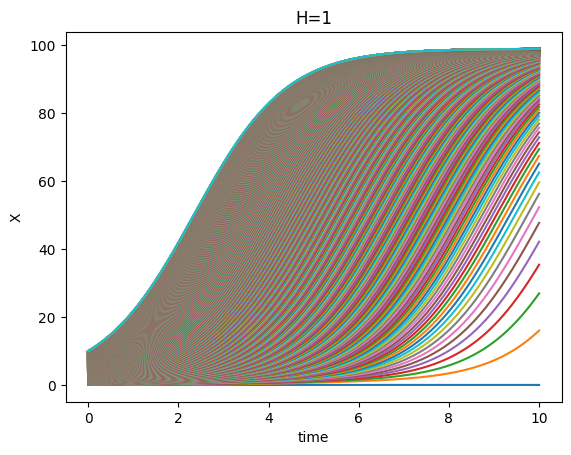

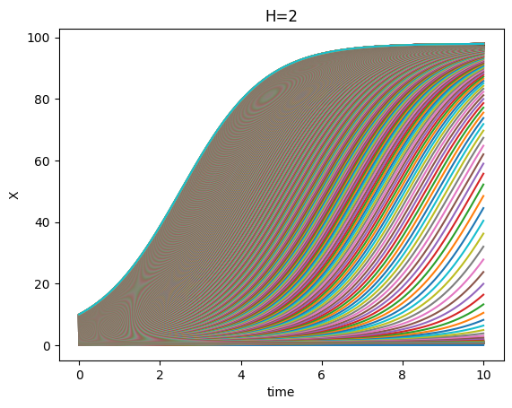

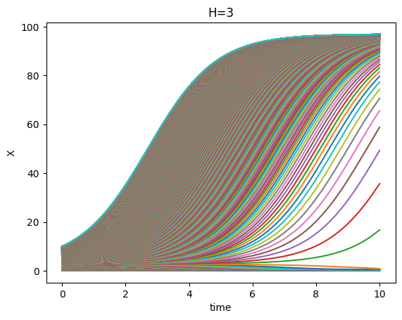

```python
# plotting results

for key in results:

    for index in range(len(x0)):
        _ = plt.plot(t, results[key][index])

    plt.xlabel("time")
    plt.ylabel("X")
    plt.title("H="+str(key))
    plt.show()
```

Since the images we got are not perfectly clear, we redo computation and plot using a longer period of time:

[figure not shown]

[figure not shown]

[figure not shown]

```python
t = np.linspace(0, 30, 20000)

results = {}

for H in H_test:

    model = cow_veg_generator(H)

    results[H] = []
    for x_init in x0:
        results[H].append(odeint(model, x_init, t))

for key in results:

    for index in range(len(x0)):
        _ = plt.plot(t, results[key][index])

    plt.xlabel("time")
    plt.ylabel("X")
    plt.title("H="+str(key))
    plt.show()
```

We can grab more information from the new plots, but still we need more details, so let's take a closer look at the behavior for small values of X:

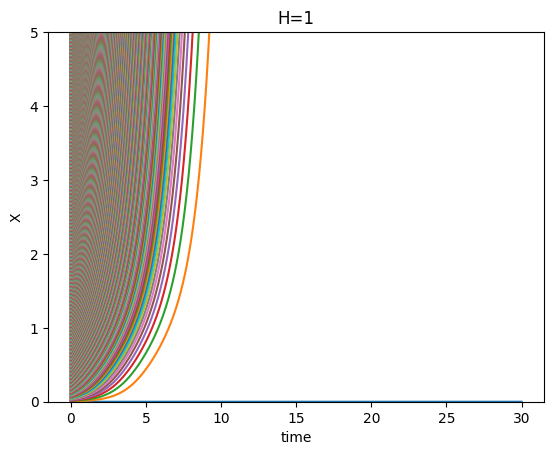

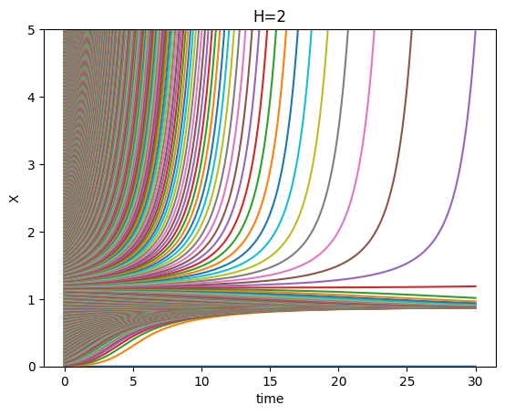

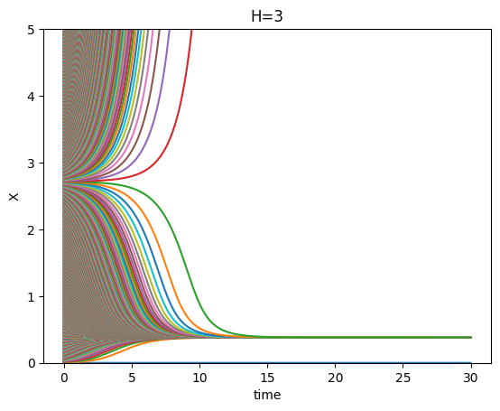

```python
for key in results:

    for index in range(len(x0)):
        _ = plt.plot(t, results[key][index])

    plt.xlabel("time")
    plt.ylabel("X")
    plt.title("H="+str(key))
    plt.ylim((0, 5))
    plt.show()
```

#### Conclusions

As we can see, the number and type of equilibrium points depend on the value of the parameter H.

Looking at the plots, in particular at the different trajectories followed depending on the initial conditions, we can guess the following things:

- $H=1$: two equilibrium points $X_e=0$ (unstable) and $X_e\simeq 100$ (stable);
- $H=2$: four equilibrium points $X_e=0$ (unstable), $X_e\simeq 0.9$ (stable), $X_e\simeq 1.1$ (unstable) and $X_e\simeq 100$ (stable);
- $H=3$: four equilibrium points $X_e=0$ (unstable), $X_e\simeq 0.4$ (stable), $X_e\simeq 2.7$ (unstable) and $X_e\simeq 100$ (stable).

We can try to add more information by just looking at the ODE (let's define $g(X)$ such that $\dot{X}=g(X)$):

- we can see that $x_e=0$ is confirmed to be always an equilibrium point, since $g(0)=0$, for any value of H;
- we can try to be more precise about the equilibrium points around 100, by observing that substituting an X close to 100 into the second term of $g(X)$ we get a number that is very close to H itself; regarding the first term, instead, we get a number that is close to the difference between 100 and X; as a consequence, we can guess that $X_e$ will be $\simeq 100-H$ (we can also see this dependency of $X_e$ from $H$ from the first set of plots, observing that the maximum value of the X axis is (automathically) set to smaller values as H increases);

In addition to that we can compute the derivative of $g(X)$ w.r.t. $X$, which is: $$ g'(X) = 1-\frac{X}{50}-H\frac{X\left(2-X\right)}{\left(X^2+1\right)^2}, $$ which is trivially $>0$ for $X=0$ for any H (confirming that $X_e=0$ is always unstable), and trivially $<0$ for $X\simeq 100$ for any H (confirming that $X_e\simeq 100$ is always stable).

## Exercise 3

```python
# defining the system's ODE solver

def system(y, t):

    traj = np.empty(len(t))
    traj[0] = y

    for i in range(1, len(t)):
        traj[i] = 0.5 * (traj[i-1]**2-3*traj[i-1]+6)

    return traj
```

```python
# defining variables values

y0 = np.linspace(1, 3, 1000)  # initial conditions
t = np.arange(11)  # time values
```

```python
# solving the system for given initial conditions

results = []
for y_init in y0:
    results.append(system(y_init, t))
```

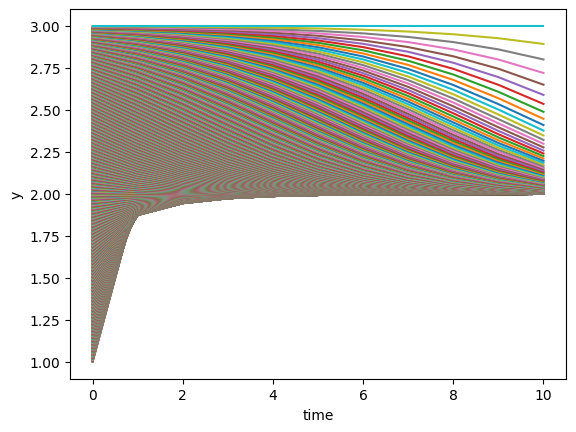

```python
# plotting results

for index in range(len(y0)):
    _ = plt.plot(t, results[index])

plt.xlabel("time")
plt.ylabel("y")
plt.show()
```

From the plot there seem to be two equilibrium points, one stable around 2 and another one unstable in 3. To check this, let's compute for larger times and replot looking more in details:

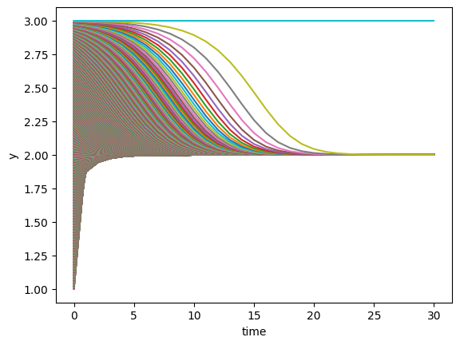

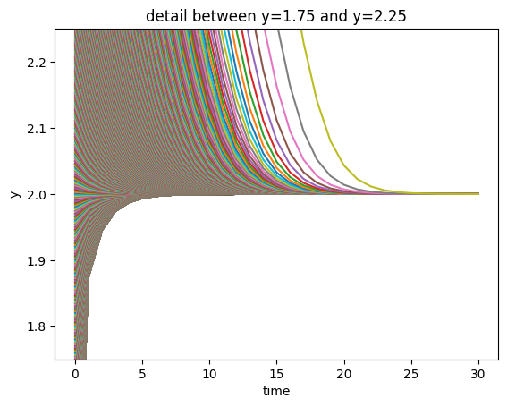

```python
t = np.arange(31)

results = []
for y_init in y0:
    results.append(system(y_init, t))

for index in range(len(y0)):
    _ = plt.plot(t, results[index])

plt.xlabel("time")
plt.ylabel("y")
plt.show()

for index in range(len(y0)):
    _ = plt.plot(t, results[index])

plt.xlabel("time")
plt.ylabel("y")
plt.ylim((1.75, 2.25))
plt.title("detail between y=1.75 and y=2.25")
plt.show()
```

#### Conclusions

The previous observations are confirmed at a closer look.